# Project-TDF-html

Jigar Patel

09/11/2021

# Introduction

The DataFrames are loaded in the environment. We can start to clean the data: The cleaning process will include the following:

- Removing null values (or substituting them with meaningful values)
- Creating or removing new columns

## Cleaning the data:

### Looking at the data:

```r
stage_data <- stage_data1
head(x = tdf_stages,2)
```

```
##   Stage       Date Distance      Origin Destination                  Type
## 1     1 2017-07-01     14.0 DÃ¼sseldorf DÃ¼sseldorf Individual time trial
## 2     2 2017-07-02    203.5 DÃ¼sseldorf      LiÃ¨ge            Flat stage
##           Winner Winner_Country
## 1 Geraint Thomas            GBR
## 2  Marcel Kittel            GER
```

```r
head(x = stage_data,2)
```

```
##   edition year stage_results_id rank time         rider age team points elapsed
## 1       1 1903          stage-1    1  13S Garin Maurice  32 <NA>    100     13S
## 2       1 1903          stage-1    2  55S  Pagie Ã‰mile  32 <NA>     70      8S
##   bib_number
## 1         NA
## 2         NA
```

```r
head(x = tdf_winners,2)
```

```
##   edition start_date   winner_name   winner_team distance time_overall
## 1       1 1903-07-01 Maurice Garin La FranÃ§aise     2428     94.55389
## 2       2 1904-07-02  Henri Cornet         Conte     2428     96.09861
##   time_margin stage_wins stages_led height weight age       born       died
## 1    2.989167          3          6   1.62     60  32 1871-03-03 1957-02-19
## 2    2.270556          1          3     NA     NA  19 1884-08-04 1941-03-18
##   full_name                 nickname birth_town birth_country nationality
## 1      <NA> The Little Chimney-sweep     Arvier         Italy    Â France
## 2      <NA>    Le rigolo (The joker)    Desvres        France    Â France
```

#### Cleaning `tdf_stages`:

Detecting the numbers of missing values in each row:

```r
# making a function to detect null values:
check_null <- function(df){
  as.data.frame(lapply(df, function(x) {length(which(is.na(x)))}))
}

# checking null values for `stage_data`
check_null(tdf_stages)
```

```
##   Stage Date Distance Origin Destination Type Winner Winner_Country
## 1     0    0        0      0           0    0      0              0
```

No Null values in this dataset.

#### Cleaning `stage_data`:

Detecting the number of rows with missing values:

```r
check_null(stage_data)
```

```
##   edition year stage_results_id rank time rider  age  team points elapsed
## 1       0    0                0    0 5617     0 3326 17159 222746    5617
##   bib_number
## 1      23534
```

Let’s look at the column `time`. It has 5617 null values. Converting the column into integer type column.

```r
# Extracting only the numerical part inside the string.
stage_data$time = (str_sub(stage_data$time,start = 1,end=-2))

# Is the data numeric?
is.numeric(stage_data$time)
```

```
## [1] FALSE
```

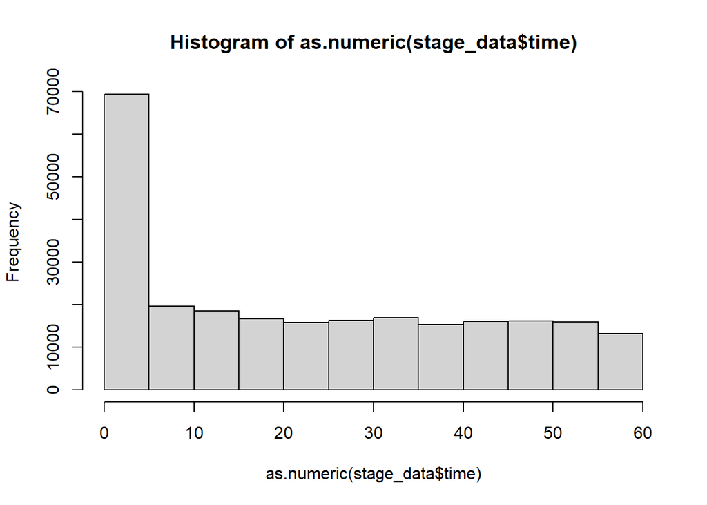

```r
# The data doesn't seem to be numeric

# Histogram of the numeric time column
hist(as.numeric(stage_data$time))
```

```r
# The mean
m <- mean(na.omit(as.numeric(stage_data$time)))
m
```

```
## [1] 23.19165
```

This mean can be substituted in place of Na values.

As the ‘time’ column is important, we cannot simply omit it.

We can see that the numbers vary from 0 to 60 seconds. We can take the average value of the racers and substitute that in place of null values.

```r
# Mean of the time column
stage_data[is.na(stage_data$time),]$time <- m
stage_data$time <- as.numeric(stage_data$time)
mean(stage_data$time)
```

```
## [1] 23.19165
```

```r
check_null(stage_data)
```

```
##   edition year stage_results_id rank time rider  age  team points elapsed
## 1       0    0                0    0    0     0 3326 17159 222746    5617
##   bib_number
## 1      23534
```

**We have successfully removed null values from the `time` column**.

We can move to `age` column.

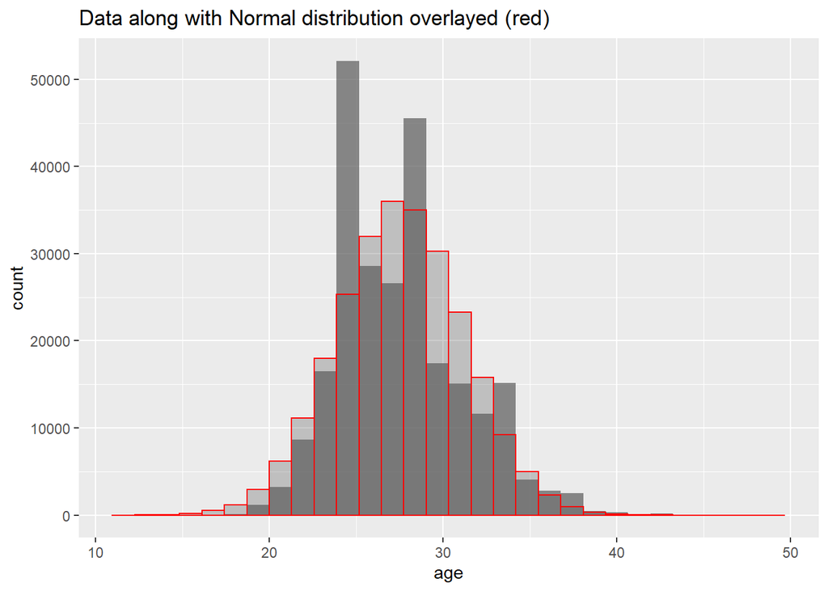

```r
# checking `age` column
mean_age <- mean(na.omit(stage_data$age))
sd_age <- sd(na.omit(stage_data$age))

pl_age_distributions <-
  ggplot(stage_data) +
  geom_histogram(aes(x = age),alpha=0.7,position='identity') +

  geom_histogram(aes(x = rnorm(nrow(stage_data),
                               mean = mean_age,
                               sd = sd_age)),color='red',
                 alpha=0.3) +
  ggtitle('Data along with Normal distribution overlayed (red)')
pl_age_distributions
```

The graph closely resembles roughly as a normal distribution, we can substitute the Na values with normally distributed ones

```r
for (i in 1:nrow(stage_data)){
  if (is.na(stage_data$age[i])){
    stage_data$age[i] = rnorm(1,mean = mean_age,sd = sd_age)

  }
}


# # dummy_example
# crs <- mtcars
# for (i in 1:nrow(crs)){
#   if (crs$mpg[i] > 20){
#     crs$cyl[i] = rnorm(1,mean = mean_age,sd = sd_age)
#   }
# }
#
# crs
```

```r
check_null(stage_data)
```

```
##   edition year stage_results_id rank time rider age  team points elapsed
## 1       0    0                0    0    0     0   0 17159 222746    5617
##   bib_number
## 1      23534
```

We will focus on `team` column.

https://github.com/rfordatascience/tidytuesday/blob/master/data/2020/2020-04-07/readme.md#:~:text=Team%20(NA%20if%20not%20on%20team)

The document tells us that if the player is not in the team the value is given to be `NA` (null). We can replace this value with `"No Team"`

```r
sum(is.na(stage_data$team))
```

```
## [1] 17159
```

```r
# for loop for replacing "" and NA with "No Team"
for (i in 1:nrow(stage_data)){
  if (stage_data$team[i] == "" |is.na(stage_data$team[i])){
    stage_data$team[i] = "No Team"
  }
}

sum(is.na(stage_data$team))
```

```
## [1] 0
```

We have successfully remove the null values from the `team` column in `stage_data` dataset and switched it to “*No team*”

We can move on to the next column which contains null values.

```r
# Extracting only the numerical part inside the string.
stage_data$elapsed = (str_sub(stage_data$elapsed,start = 1,end=-2))

# Is the data numeric?
is.numeric(stage_data$elapsed)
```

```
## [1] FALSE
```

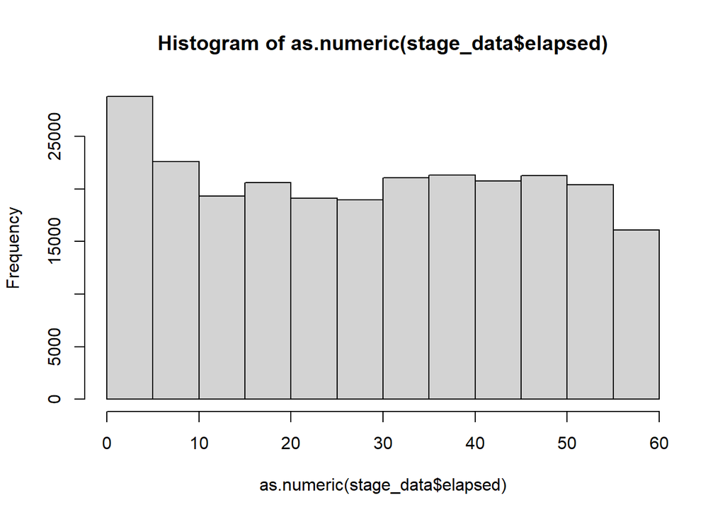

```r
# The data doesn't seem to be numeric

# Histogram of the numeric time column
hist(as.numeric(stage_data$elapsed))
```

```r
# The mean
m <- mean(na.omit(as.numeric(stage_data$elapsed)))
m
```

```
## [1] 29.01832
```

This mean value can be substituted in place of Na values.

As the ‘elapsed’ column is important, we cannot simply omit it.

We can see that the numbers vary from 0 to 60 seconds. We can take the average value of the racers and substitute that in place of null values.

```r
# Mean of the time column
stage_data[is.na(stage_data$elapsed),]$elapsed <- m
stage_data$elapsed <- as.numeric(stage_data$elapsed)
mean(stage_data$elapsed)
```

```
## [1] 29.01832
```

```r
check_null(stage_data)
```

```
##   edition year stage_results_id rank time rider age team points elapsed
## 1       0    0                0    0    0     0   0    0 222746       0
##   bib_number
## 1      23534
```

We are done with `elapsed` column. Moving on to other columns.

```r
check_null(stage_data)
```

```
##   edition year stage_results_id rank time rider age team points elapsed
## 1       0    0                0    0    0     0   0    0 222746       0
##   bib_number
## 1      23534
```

Removing the `points` column, since there are too many missing values.

```r
# removing the `points` column
stage_data <- stage_data %>% select(-c("points"))
```

```r
check_null(stage_data)
```

```
##   edition year stage_results_id rank time rider age team elapsed bib_number
## 1       0    0                0    0    0     0   0    0       0      23534
```

**Bib_number visualization**:

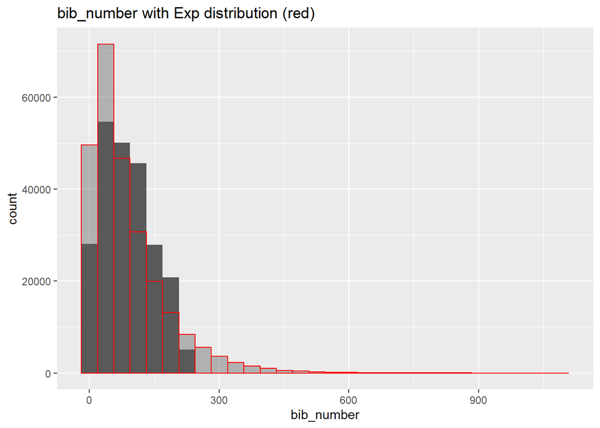

```r
mean_bib <- mean(na.omit(stage_data$bib_number))

pl_bib_number_distributions <-
  ggplot(stage_data) +
  geom_histogram(aes(x = bib_number)) +
  geom_histogram(aes(rexp(nrow(stage_data),
                          1/mean_bib)),
                 color='red',
                 alpha=0.4) +
  ggtitle("bib_number with Exp distribution (red)")
pl_bib_number_distributions
```

We can replace the null values with the exponentially distributed values.

```r
for (i in 1:nrow(stage_data)){
  if (is.na(stage_data$bib_number[i])){
    stage_data$bib_number[i] = rexp(n = 1,rate = 1/mean_bib)

  }
}
```

Checking the number of columns with still hold null values

```r
check_null(stage_data)
```

```
##   edition year stage_results_id rank time rider age team elapsed bib_number
## 1       0    0                0    0    0     0   0    0       0          0
```

**We have successfully cleaned the stage_data.csv. We will now move forward to `tdf_winners.csv`

#### Cleaning `tdf_winners`:

```r
check_null(tdf_winners)
```

```
##   edition start_date winner_name winner_team distance time_overall time_margin
## 1       0          0           0           0        0            8           8
##   stage_wins stages_led height weight age born died full_name nickname
## 1          0          0     40     39   0    0   50        60       32
##   birth_town birth_country nationality
## 1          0             0           0
```

Plotting the the `height` column and seeing how it is distributed.

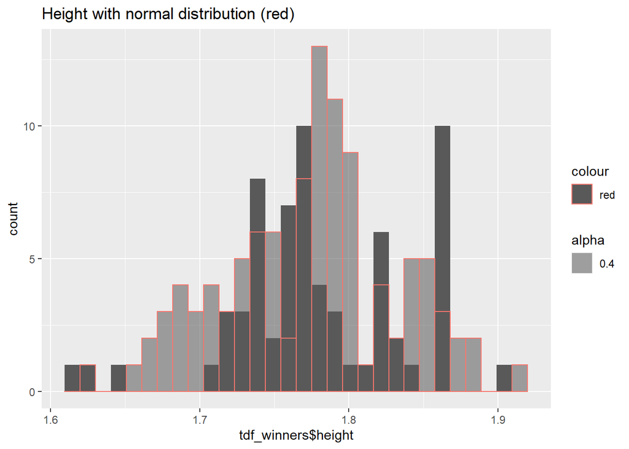

```r
par(mfrow=c(1,2))

 height_with_distributions <- ggplot(tdf_winners) + geom_histogram(data = tdf_winners,aes(x=tdf_winners$height)) +
  geom_histogram(data = tdf_winners,
                 aes(x=rnorm(nrow(tdf_winners),
                             mean = mean(na.omit(tdf_winners$height)),
                             sd = sd(na.omit(tdf_winners$height))),
                     color= 'red', alpha=0.4)) +
  ggtitle("Height with normal distribution (red)")

weight_with_distributions <-ggplot(tdf_winners) + geom_histogram(data = tdf_winners,aes(x=tdf_winners$weight)) +
  geom_histogram(data = tdf_winners,
                 aes(x=rnorm(nrow(tdf_winners),
                             mean = mean(na.omit(tdf_winners$weight)),
                             sd = sd(na.omit(tdf_winners$weight))),
                     color= 'red', alpha=0.4)) +
  ggtitle('Weight with normal distribution (red)')

height_with_distributions
```

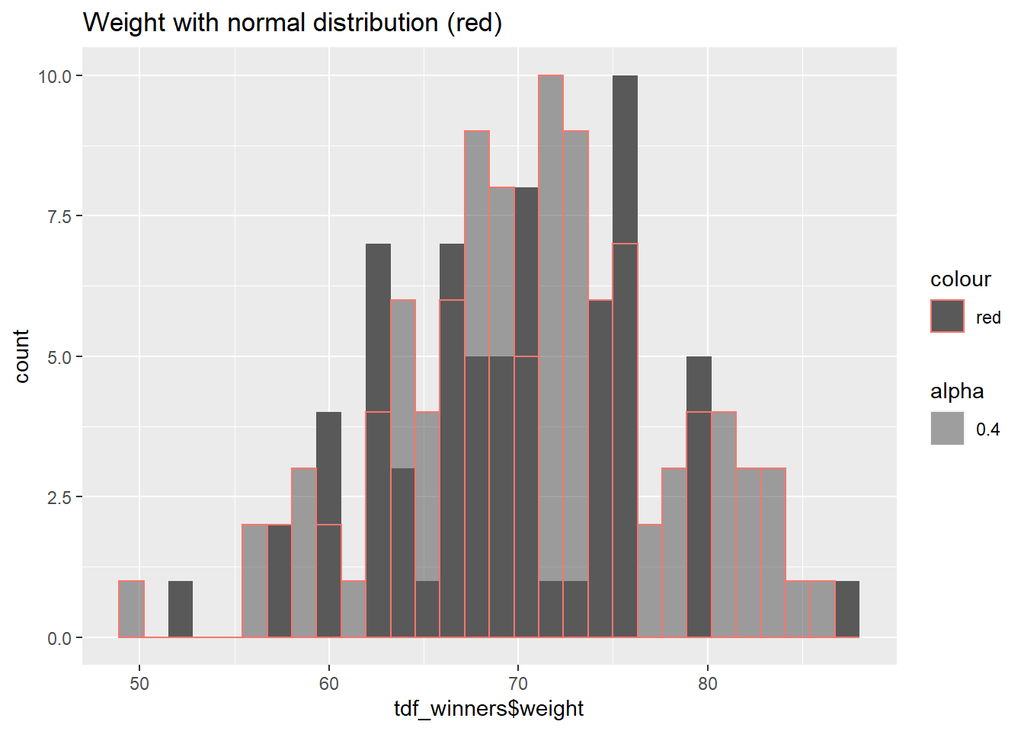

```r
weight_with_distributions
```

The data looks like it can be approximated with a normal distribution.

We can substitute the null values in `height` and `weight` with normal distribution.

```r
for (i in 1:nrow(tdf_winners)){
  if (is.na(tdf_winners$height[i])){
    tdf_winners$height[i] = rnorm(1,
                             mean = mean(na.omit(tdf_winners$height)),
                             sd = sd(na.omit(tdf_winners$height)))

  }
}

for (i in 1:nrow(tdf_winners)){
  if (is.na(tdf_winners$weight[i])){
    tdf_winners$weight[i] = rnorm(1,
                             mean = mean(na.omit(tdf_winners$weight)),
                             sd = sd(na.omit(tdf_winners$weight)))

  }
}
```

```r
check_null(tdf_winners)
```

```
##   edition start_date winner_name winner_team distance time_overall time_margin
## 1       0          0           0           0        0            8           8
##   stage_wins stages_led height weight age born died full_name nickname
## 1          0          0      0      0   0    0   50        60       32
##   birth_town birth_country nationality
## 1          0             0           0
```

We have removed null values from `height` and `weight` columns.

Dropping not so useful columns

```r
tdf_winners <- subset(tdf_winners, select=-c(nickname,full_name,died))

check_null(tdf_winners)
```

```
##   edition start_date winner_name winner_team distance time_overall time_margin
## 1       0          0           0           0        0            8           8
##   stage_wins stages_led height weight age born birth_town birth_country
## 1          0          0      0      0   0    0          0             0
##   nationality
## 1           0
```

**visualization of `time_overall` and `time_margin`**

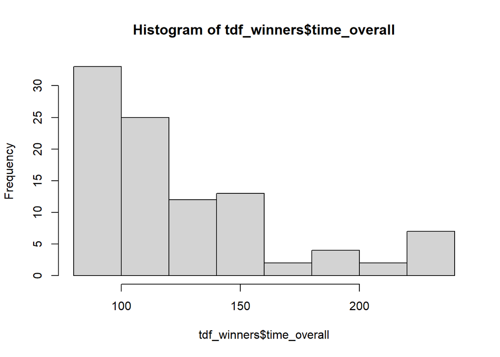

```r
hist(tdf_winners$time_overall)
```

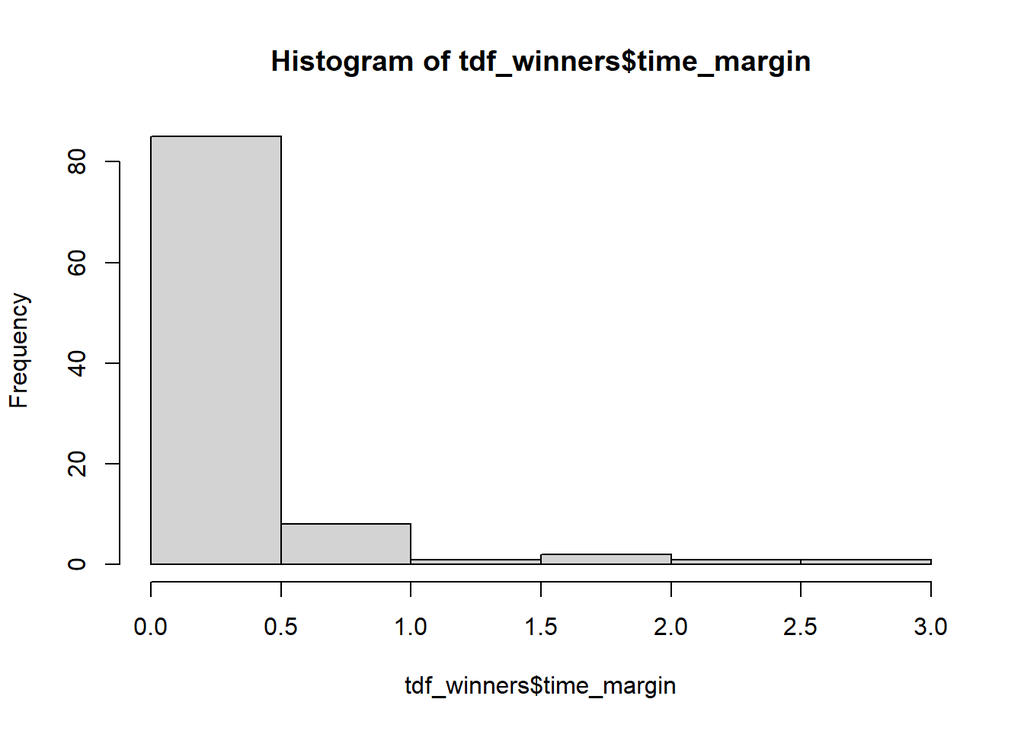

```r
hist(tdf_winners$time_margin)
```

They both can follow an exponential distribution.

```r
# We can substitute the null values with exponential distributed values
for (i in 1:nrow(tdf_winners)){
  if (is.na(tdf_winners$time_overall[i])){
    tdf_winners$time_overall[i]=rexp(1,
                                    1/mean(na.omit(tdf_winners$time_overall)))
  }
}

for (i in 1:nrow(tdf_winners)){
  if (is.na(tdf_winners$time_margin[i])){
    tdf_winners$time_margin[i]=rexp(1,
                                    1/mean(na.omit(tdf_winners$time_margin)))
  }
}

check_null(tdf_winners)
```

```
##   edition start_date winner_name winner_team distance time_overall time_margin
## 1       0          0           0           0        0            0           0
##   stage_wins stages_led height weight age born birth_town birth_country
## 1          0          0      0      0   0    0          0             0
##   nationality
## 1           0
```

**All the data has now been cleaned**

## Saving the files:

```r
check_null(tdf_stages)
```

```
##   Stage Date Distance Origin Destination Type Winner Winner_Country
## 1     0    0        0      0           0    0      0              0
```

```r
check_null(stage_data)
```

```
##   edition year stage_results_id rank time rider age team elapsed bib_number
## 1       0    0                0    0    0     0   0    0       0          0
```

```r
check_null(tdf_winners)
```

```
##   edition start_date winner_name winner_team distance time_overall time_margin
## 1       0          0           0           0        0            0           0
##   stage_wins stages_led height weight age born birth_town birth_country
## 1          0          0      0      0   0    0          0             0
##   nationality
## 1           0
```

```r
write.csv(tdf_stages,'CLEANED_tdf_stages_from_R.csv')
write.csv(stage_data,'CLEANED_stage_data_from_R.csv')
write.csv(tdf_winners,'CLEANED_tdf_winners_from_R.csv')
```